# SPWM Notebook

TODO: check sub78’s raw data to explain low accuracy data

# SPWM PRE DATA ANALYSIS

## Data Prep

Getting the Data ready for analysis Defaults: R uses dummy coding as it’s default. In this sample, the control group and the four_m will be the dummy variables in the analysis. So all Estimates are relative to these dummy variables

### Load Requisite R Packages

note: some of these may not actually be used.

```r
library(ggplot2)
library(lme4)
library(languageR)
library(lmerTest) #give p-values from mixed models
library(influence.ME)
library(plyr) # magic
library(scales) #for making percents on the y-axis of graphs
```

### Read in the dataset (in current directory)

```r
SPWM_data = read.table("SPWM_R_format.csv", header = TRUE, sep = ",")
```

### omit missing data (e.g. from practice trials)

```r
SPWM_data = na.omit(SPWM_data)
head(SPWM_data, n = 20)
```

```
##    subject session        group stimtype ACC   RT
## 9        5       1 Experimental  four_nm   0  823
## 10       5       1 Experimental  four_nm   1  812
## 11       5       1 Experimental   four_m   1 1090
## 12       5       1 Experimental  four_nm   1  763
## 13       5       1 Experimental  four_nm   1 1235
## 14       5       1 Experimental  four_nm   1  871
## 15       5       1 Experimental  four_nm   1 1083
## 16       5       1 Experimental   four_m   1 1286
## 17       5       1 Experimental   four_m   0 1063
## 18       5       1 Experimental   four_m   0  851
## 19       5       1 Experimental   four_m   1  663
## 20       5       1 Experimental   four_m   1  803
## 21       5       1 Experimental   four_m   1  825
## 22       5       1 Experimental   four_m   1 1037
## 23       5       1 Experimental   four_m   0  809
## 24       5       1 Experimental  four_nm   1 1183
## 25       5       1 Experimental   four_m   1  966
## 26       5       1 Experimental  four_nm   1 1206
## 27       5       1 Experimental  four_nm   1  763
## 28       5       1 Experimental  four_nm   1 1251
```

### Omit the Undefined group from the data and specify group as a factor

```r
SPWM_data <- subset(SPWM_data,group=="Control" | group=="Experimental")
SPWM_data$group <- factor(SPWM_data$group)
summary(SPWM_data)
```

```
##     subject         session               group         stimtype
##  Min.   :  5.0   Min.   :1.000   Control     :3780          :   0
##  1st Qu.: 45.0   1st Qu.:1.000   Experimental:3360   four_m :3570
##  Median : 98.0   Median :1.000                       four_nm:3570
##  Mean   :104.4   Mean   :1.471
##  3rd Qu.:166.0   3rd Qu.:2.000
##  Max.   :209.0   Max.   :2.000
##       ACC               RT
##  Min.   :0.0000   Min.   :   0
##  1st Qu.:1.0000   1st Qu.: 922
##  Median :1.0000   Median :1138
##  Mean   :0.7577   Mean   :1101
##  3rd Qu.:1.0000   3rd Qu.:1375
##  Max.   :1.0000   Max.   :1897
```

```r
contrasts(SPWM_data$group)
```

```
##              Experimental
## Control                 0
## Experimental            1
```

### Omit the Undefined stimtype and specify stimtype as a factor

```r
SPWM_data <- subset(SPWM_data,stimtype=="four_m" | stimtype=="four_nm")
SPWM_data$stimtype <- factor(SPWM_data$stimtype)
summary(SPWM_data)
```

```
##     subject         session               group         stimtype
##  Min.   :  5.0   Min.   :1.000   Control     :3780   four_m :3570
##  1st Qu.: 45.0   1st Qu.:1.000   Experimental:3360   four_nm:3570
##  Median : 98.0   Median :1.000
##  Mean   :104.4   Mean   :1.471
##  3rd Qu.:166.0   3rd Qu.:2.000
##  Max.   :209.0   Max.   :2.000
##       ACC               RT
##  Min.   :0.0000   Min.   :   0
##  1st Qu.:1.0000   1st Qu.: 922
##  Median :1.0000   Median :1138
##  Mean   :0.7577   Mean   :1101
##  3rd Qu.:1.0000   3rd Qu.:1375
##  Max.   :1.0000   Max.   :1897
```

```r
contrasts(SPWM_data$stimtype)
```

```
##         four_nm
## four_m        0
## four_nm       1
```

### Isolate the session to the first session

```r
SPWM_data_pre <- subset(SPWM_data, session==1)
SPWM_data_pre$session <- factor(SPWM_data_pre$session)
summary(SPWM_data_pre)
```

```
##     subject      session           group         stimtype
##  Min.   :  5.0   1:3780   Control     :2040   four_m :1890
##  1st Qu.: 45.0            Experimental:1740   four_nm:1890
##  Median : 98.0
##  Mean   :105.4
##  3rd Qu.:172.0
##  Max.   :209.0
##       ACC               RT
##  Min.   :0.0000   Min.   :   0
##  1st Qu.:0.0000   1st Qu.: 902
##  Median :1.0000   Median :1142
##  Mean   :0.7429   Mean   :1093
##  3rd Qu.:1.0000   3rd Qu.:1387
##  Max.   :1.0000   Max.   :1897
```

### Specify subject as a factor

```r
SPWM_data_pre$subject <- as.factor(SPWM_data_pre$subject)

summary(SPWM_data_pre)
```

```
##     subject     session           group         stimtype
##  5      :  60   1:3780   Control     :2040   four_m :1890
##  6      :  60            Experimental:1740   four_nm:1890
##  7      :  60
##  8      :  60
##  9      :  60
##  10     :  60
##  (Other):3420
##       ACC               RT
##  Min.   :0.0000   Min.   :   0
##  1st Qu.:0.0000   1st Qu.: 902
##  Median :1.0000   Median :1142
##  Mean   :0.7429   Mean   :1093
##  3rd Qu.:1.0000   3rd Qu.:1387
##  Max.   :1.0000   Max.   :1897
##
```

## SPWN Accuracy Analysis

### Print Accuracy data for each subject for each group

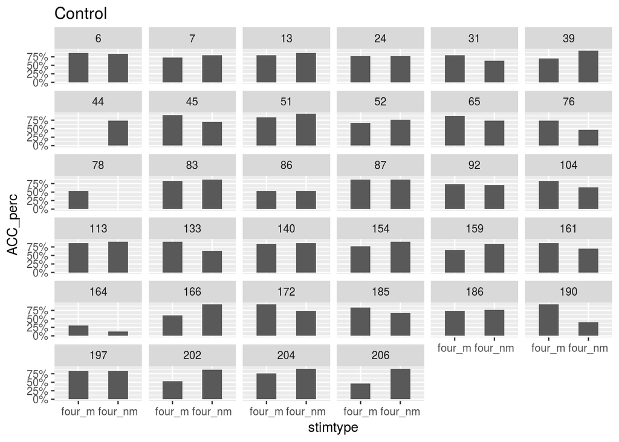

```r
#Control Group Data
SPWM_data_pre_control <- subset(SPWM_data_pre, group=="Control")
#change binary data to a percent
SPWM_data_pre_control_percent <- ddply(SPWM_data_pre_control, .(stimtype, subject), summarize, ACC_perc = mean(ACC))

#Experimental Group Data
SPWM_data_pre_experimental <- subset(SPWM_data_pre, group=="Experimental")
#change binary data to a percent
SPWM_data_pre_experimental_percent <- ddply(SPWM_data_pre_experimental, .(stimtype, subject), summarize, ACC_perc = mean(ACC))

ggplot(data = SPWM_data_pre_control_percent, aes( x = stimtype, y = ACC_perc)) + geom_bar(stat = "identity", width = 0.5) + facet_wrap(~subject) + scale_y_continuous(labels=percent) + scale_x_discrete(labels=c("four_m","four_nm")) + ggtitle("Control")
```

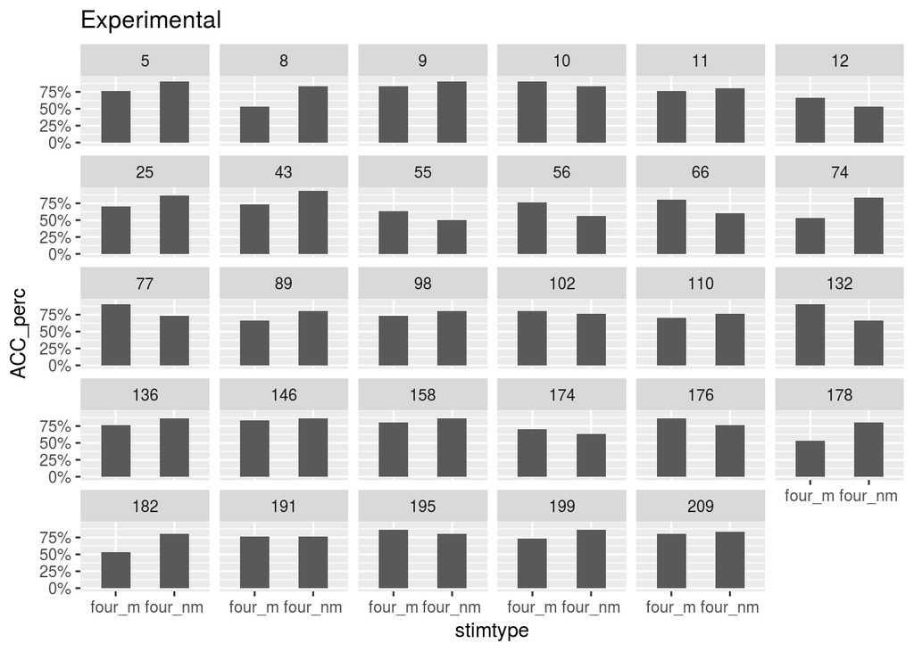

```r
ggplot(data = SPWM_data_pre_experimental_percent, aes( x = stimtype, y = ACC_perc)) + geom_bar(stat = "identity", width = 0.5) + facet_wrap(~subject) + scale_y_continuous(labels=percent) +  scale_x_discrete(labels=c("four_m","four_nm")) + ggtitle("Experimental")
```

**Conclusion**: sub78,sub164, and sub190 have worrying low accuracy for the non-matching conditions. In fact sub78 did not get any right, should check the raw data to see if they were pressing the wrong key. Otherwise data appear fine.

### Model Accuracy (Logit)

```r
SPWM_ACC_model<-glmer(ACC ~ group*stimtype + (1|subject), family=binomial, data=SPWM_data_pre, verbose=TRUE)
```

```
## start par. =  1 fn =  4178.382
## At return
## eval:  16 fn:      4156.6575 par: 0.568593
## (NM) 20: f = 4156.61 at   0.568593    1.08103  0.0289273 -0.0162457   0.202788
## (NM) 40: f = 4156.61 at   0.568269    1.07427  0.0257224 -0.0176453   0.209892
## (NM) 60: f = 4156.61 at   0.568252    1.07462  0.0291035 -0.0178724   0.206448
## (NM) 80: f = 4156.61 at   0.568706    1.07381  0.0303415 -0.0163087   0.205103
## (NM) 100: f = 4156.61 at   0.568508    1.07386  0.0298786 -0.0162895   0.205259
## (NM) 120: f = 4156.61 at   0.568493    1.07389  0.0298383 -0.0163745    0.20532
## (NM) 140: f = 4156.61 at    0.56849    1.07401  0.0296978 -0.0164474   0.205341
## (NM) 160: f = 4156.61 at   0.568488      1.074  0.0296953 -0.0164574   0.205388
```

```r
summary(SPWM_ACC_model)
```

```
## Generalized linear mixed model fit by maximum likelihood (Laplace
##   Approximation) [glmerMod]
##  Family: binomial  ( logit )
## Formula: ACC ~ group * stimtype + (1 | subject)
##    Data: SPWM_data_pre
##
##      AIC      BIC   logLik deviance df.resid
##   4166.6   4197.8  -2078.3   4156.6     3775
##
## Scaled residuals:
##     Min      1Q  Median      3Q     Max
## -2.4239 -0.6767  0.4874  0.5770  1.4899
##
## Random effects:
##  Groups  Name        Variance Std.Dev.
##  subject (Intercept) 0.3232   0.5685
## Number of obs: 3780, groups:  subject, 63
##
## Fixed effects:
##                                   Estimate Std. Error z value Pr(>|z|)
## (Intercept)                        1.07399    0.12281   8.745   <2e-16 ***
## groupExperimental                  0.02971    0.18019   0.165    0.869
## stimtypefour_nm                   -0.01644    0.10433  -0.158    0.875
## groupExperimental:stimtypefour_nm  0.20536    0.15443   1.330    0.184
## ---
## Signif. codes:  0 '***' 0.001 '**' 0.01 '*' 0.05 '.' 0.1 ' ' 1
##
## Correlation of Fixed Effects:
##             (Intr) grpExp stmty_
## grpExprmntl -0.681
## stmtypfr_nm -0.426  0.291
## grpExprmn:_  0.288 -0.418 -0.676
```

## Reaction Time Analysis

### Format RT data

(subset for RTs when they are accurate, greater than 200ms, and less than 5000 ms) (speed wasn’t as important in this task) See how many observations are lost when we subset the data

```r
#all observations
print("All Data")
```

```
## [1] "All Data"
```

```r
All_data <- length(SPWM_data_pre$RT)
summary(SPWM_data_pre)
```

```
##     subject     session           group         stimtype
##  5      :  60   1:3780   Control     :2040   four_m :1890
##  6      :  60            Experimental:1740   four_nm:1890
##  7      :  60
##  8      :  60
##  9      :  60
##  10     :  60
##  (Other):3420
##       ACC               RT
##  Min.   :0.0000   Min.   :   0
##  1st Qu.:0.0000   1st Qu.: 902
##  Median :1.0000   Median :1142
##  Mean   :0.7429   Mean   :1093
##  3rd Qu.:1.0000   3rd Qu.:1387
##  Max.   :1.0000   Max.   :1897
##
```

```r
#remove innacurate responses
print("Removed innacurate trials (from all data dataframe)")
```

```
## [1] "Removed innacurate trials (from all data dataframe)"
```

```r
SPWM_data_pre_RT <- subset(SPWM_data_pre, ACC==1)
All_Acc_Data <- length(SPWM_data_pre_RT$RT)
summary(SPWM_data_pre_RT)
```

```
##     subject     session           group         stimtype         ACC
##  51     :  53   1:2808   Control     :1487   four_m :1391   Min.   :1
##  113    :  53            Experimental:1321   four_nm:1417   1st Qu.:1
##  9      :  52                                               Median :1
##  10     :  52                                               Mean   :1
##  87     :  52                                               3rd Qu.:1
##  6      :  51                                               Max.   :1
##  (Other):2495
##        RT
##  Min.   : 145.0
##  1st Qu.: 963.8
##  Median :1158.0
##  Mean   :1177.5
##  3rd Qu.:1387.0
##  Max.   :1897.0
##
```

```r
#remove short and long RTs
print("Removed slow and fast RTs")
```

```
## [1] "Removed slow and fast RTs"
```

```r
SPWM_data_pre_RT <- subset(SPWM_data_pre_RT, RT>200 & RT<5000)
filtered_data <- length(SPWM_data_pre_RT$RT)
summary(SPWM_data_pre_RT)
```

```
##     subject     session           group         stimtype         ACC
##  51     :  53   1:2807   Control     :1487   four_m :1390   Min.   :1
##  113    :  53            Experimental:1320   four_nm:1417   1st Qu.:1
##  9      :  52                                               Median :1
##  10     :  52                                               Mean   :1
##  87     :  52                                               3rd Qu.:1
##  6      :  51                                               Max.   :1
##  (Other):2494
##        RT
##  Min.   : 401
##  1st Qu.: 964
##  Median :1158
##  Mean   :1178
##  3rd Qu.:1387
##  Max.   :1897
##
```

```r
print("Percentage of Data Removed")
```

```
## [1] "Percentage of Data Removed"
```

```r
perc_data_rm <- (1 - (filtered_data/All_Acc_Data)) * 100
perc_data_rm
```

```
## [1] 0.03561254
```

**Conclusion**: Almost no data is filtered out because of the RTs, looks like one fast response was removed.

### Graph RT data

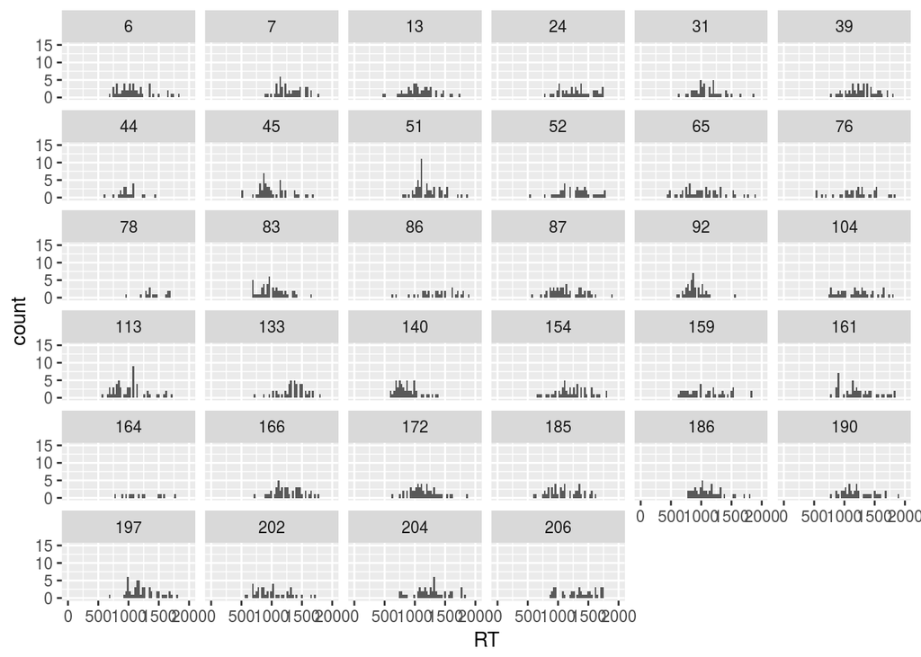

```r
#hist(subset(SPWM_data_pre_RT, group=="Control")$RT,ylim=c(0,300))
#hist(subset(SPWM_data_pre_RT, group=="Experimental")$RT,ylim=c(0,300))

SPWM_data_pre_RT_control <- subset(SPWM_data_pre_RT, group=="Control")

SPWM_data_pre_RT_experimental <- subset(SPWM_data_pre_RT, group=="Experimental")

#collapsing across stimtype (four_m, four_nm), not enough data to make a good histogram, and the graphs become too crowded if I include stimtype as a facet
RT_hist_control <- ggplot(data = SPWM_data_pre_RT_control, aes(RT)) + geom_histogram(binwidth = 30) + facet_wrap(~subject) + scale_y_continuous(limits = c(0,15)) + scale_x_continuous(limits = c(0,2000))
print(RT_hist_control)
```

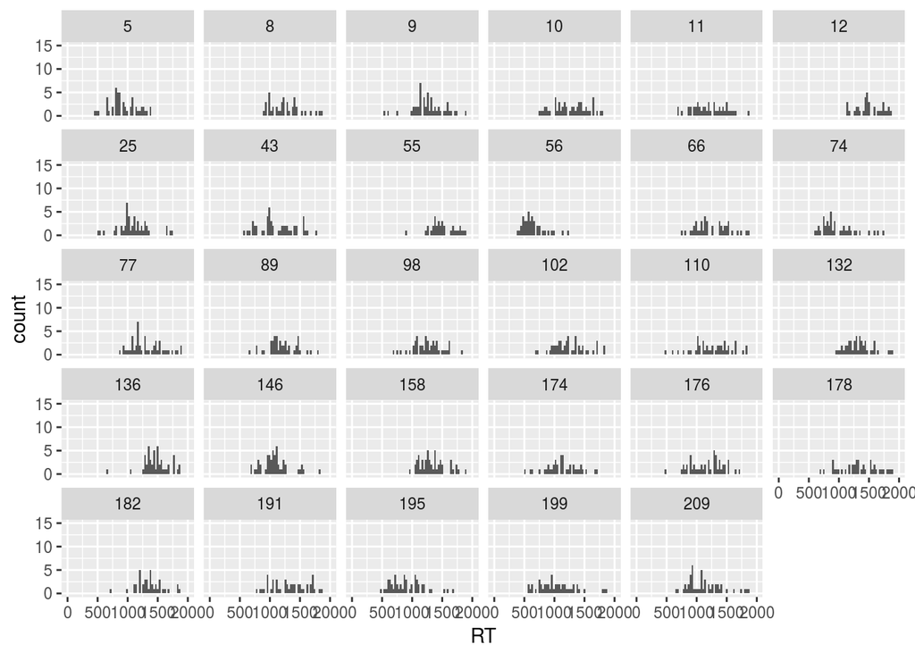

```r
RT_hist_experimental <- ggplot(data = SPWM_data_pre_RT_experimental, aes(RT)) + geom_histogram(binwidth = 30) + facet_wrap(~subject) + scale_y_continuous(limits = c(0,15)) + scale_x_continuous(limits = c(0,2000))
print(RT_hist_experimental)
```

**Conclusion**: this RT data does not need to be transformed, looks roughly normal, but I will transform it anyway to see how it looks

### Log Transform RT data

```r
SPWM_data_pre_RT$log_RT <- log(1/SPWM_data_pre_RT$RT)
```

Step 13) Graph RT data that should look more normally distributed

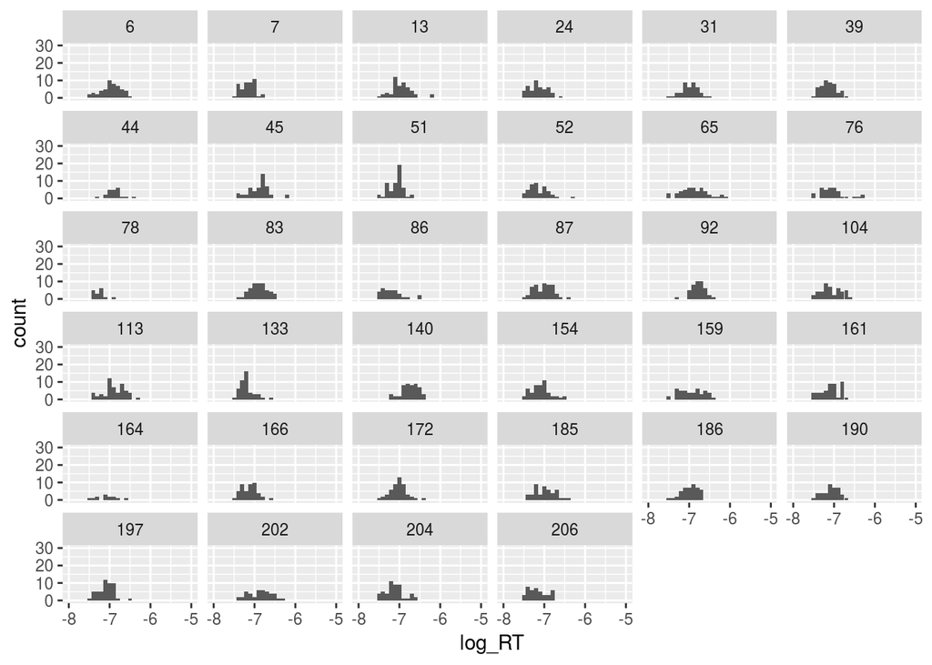

```r
SPWM_data_pre_RT_control <- subset(SPWM_data_pre_RT, group=="Control")

SPWM_data_pre_RT_experimental <- subset(SPWM_data_pre_RT, group=="Experimental")

#collapsing across stimtype (four_m, four_nm), not enough data to make a good histogram, and the graphs become too crowded if I include stimtype as a facet
RT_hist_control <- ggplot(data = SPWM_data_pre_RT_control, aes(log_RT)) + geom_histogram(binwidth = .1) + facet_wrap(~subject) + scale_y_continuous(limits = c(0,30)) + scale_x_continuous(limits = c(-8,-5))
print(RT_hist_control)
```

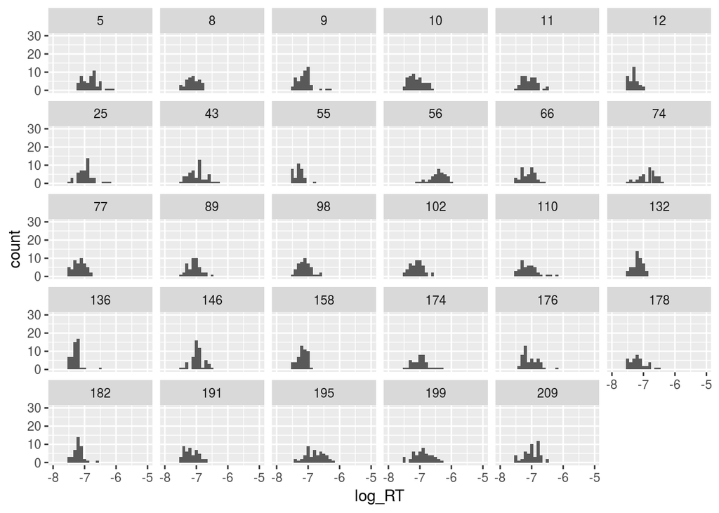

```r
RT_hist_experimental <- ggplot(data = SPWM_data_pre_RT_experimental, aes(log_RT)) + geom_histogram(binwidth = .1) + facet_wrap(~subject) + scale_y_continuous(limits = c(0,30)) + scale_x_continuous(limits = c(-8,-5))
print(RT_hist_experimental)
```

**Conclusion**: Using untransformed data because they look more normal (at least overall)

### Model RT

```r
SPWM_RT_model <- lmer(RT ~ group*stimtype + (1|subject), data = SPWM_data_pre_RT)
summary(SPWM_RT_model)
```

```
## Linear mixed model fit by REML t-tests use Satterthwaite approximations
##   to degrees of freedom [lmerMod]
## Formula: RT ~ group * stimtype + (1 | subject)
##    Data: SPWM_data_pre_RT
##
## REML criterion at convergence: 39331.2
##
## Scaled residuals:
##     Min      1Q  Median      3Q     Max
## -3.0259 -0.6632 -0.1078  0.6196  3.2882
##
## Random effects:
##  Groups   Name        Variance Std.Dev.
##  subject  (Intercept) 23978    154.8
##  Residual             67758    260.3
## Number of obs: 2807, groups:  subject, 63
##
## Fixed effects:
##                                   Estimate Std. Error       df t value
## (Intercept)                       1160.461     28.306   68.500  40.996
## groupExperimental                   54.594     41.644   68.100   1.311
## stimtypefour_nm                      6.932     13.774 2771.200   0.503
## groupExperimental:stimtypefour_nm  -26.540     19.931 2761.800  -1.332
##                                   Pr(>|t|)
## (Intercept)                         <2e-16 ***
## groupExperimental                    0.194
## stimtypefour_nm                      0.615
## groupExperimental:stimtypefour_nm    0.183
## ---
## Signif. codes:  0 '***' 0.001 '**' 0.01 '*' 0.05 '.' 0.1 ' ' 1
##
## Correlation of Fixed Effects:
##             (Intr) grpExp stmty_
## grpExprmntl -0.680
## stmtypfr_nm -0.240  0.163
## grpExprmn:_  0.166 -0.241 -0.691
```

### Model log_RT

Note: maybe the raw RTs do violate assumptions of normality

```r
SPWM_log_RT_model <- lmer(log_RT ~ group*stimtype + (1|subject), data = SPWM_data_pre_RT)
summary(SPWM_log_RT_model)
```

```
## Linear mixed model fit by REML t-tests use Satterthwaite approximations
##   to degrees of freedom [lmerMod]
## Formula: log_RT ~ group * stimtype + (1 | subject)
##    Data: SPWM_data_pre_RT
##
## REML criterion at convergence: -81.3
##
## Scaled residuals:
##     Min      1Q  Median      3Q     Max
## -2.8420 -0.6610  0.0010  0.5924  3.9733
##
## Random effects:
##  Groups   Name        Variance Std.Dev.
##  subject  (Intercept) 0.02169  0.1473
##  Residual             0.05286  0.2299
## Number of obs: 2807, groups:  subject, 63
##
## Fixed effects:
##                                     Estimate Std. Error         df
## (Intercept)                         -7.02265    0.02670   67.60000
## groupExperimental                   -0.03989    0.03929   67.20000
## stimtypefour_nm                     -0.01038    0.01217 2761.70000
## groupExperimental:stimtypefour_nm    0.02334    0.01761 2753.30000
##                                    t value Pr(>|t|)
## (Intercept)                       -263.037   <2e-16 ***
## groupExperimental                   -1.015    0.314
## stimtypefour_nm                     -0.853    0.394
## groupExperimental:stimtypefour_nm    1.326    0.185
## ---
## Signif. codes:  0 '***' 0.001 '**' 0.01 '*' 0.05 '.' 0.1 ' ' 1
##
## Correlation of Fixed Effects:
##             (Intr) grpExp stmty_
## grpExprmntl -0.680
## stmtypfr_nm -0.225  0.153
## grpExprmn:_  0.155 -0.225 -0.691
```

**Conclusion**: The trending difference disappeared (now we have to decide which analysis is more valid), thought: get a quantitative measure for skew and normality and see if log or raw RT is better.

## Conclusions:

Good: No statistically significant differences between groups in either ACC or RT